# Modelos

Autor/a

Mario Camacho

Fecha de publicación

23 abril 2026

Resumen

Work in progress

**Stakeholder:** Jose L Merino Rivas **Centro:** Hospital del Henares  
**Fecha última modificación:** 23 abril 2026

## Data modelos

### Ejemplo

```
# A tibble: 7 × 7
     id Aleatorización Mes      `Pauta (código)` Ferritina cambio_ferritina_t0
  <dbl> <fct>          <ord>    <fct>                <dbl>               <dbl>
1     1 Ferinject      0 meses  <NA>                   414                   0
2     1 Ferinject      2 meses  1                      418                   4
3     1 Ferinject      4 meses  1                      308                -106
4     1 Ferinject      6 meses  <NA>                   215                -199
5     1 Ferinject      8 meses  <NA>                   183                -231
6     1 Ferinject      10 meses <NA>                   216                -198
7     1 Ferinject      12 meses <NA>                   193                -221
# ℹ 1 more variable: cambio_ferritina_tmenos1 <dbl>
```

### Distribución de la variable respuesta

NO ES NECESARIA NINGUNA SUPOSICIÓN SOBRE LA DISTRIBUCIÓN DE LA VARIABLE RESPUESTA, es simple curiosidad.

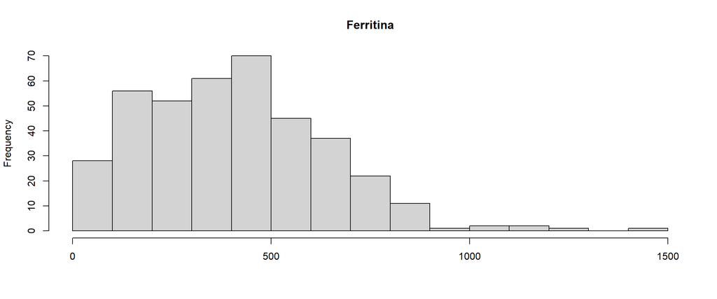

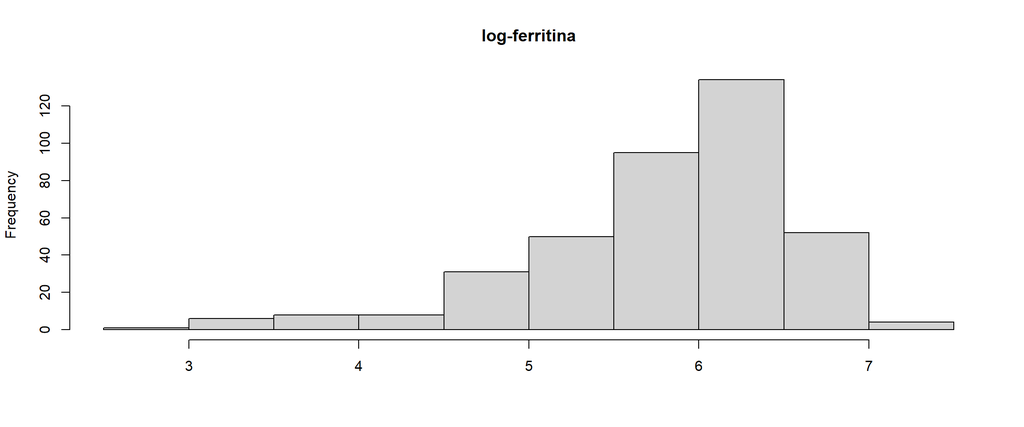

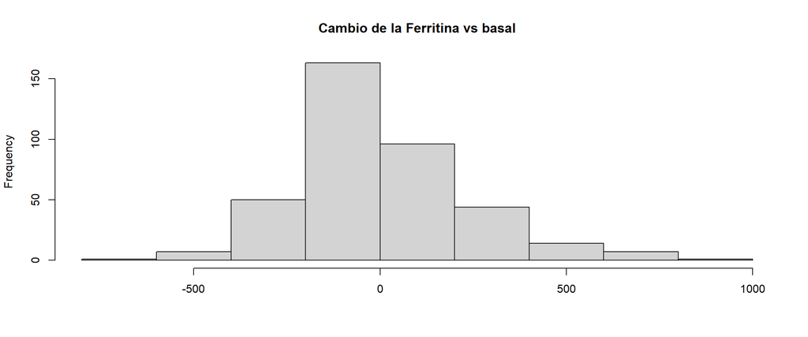

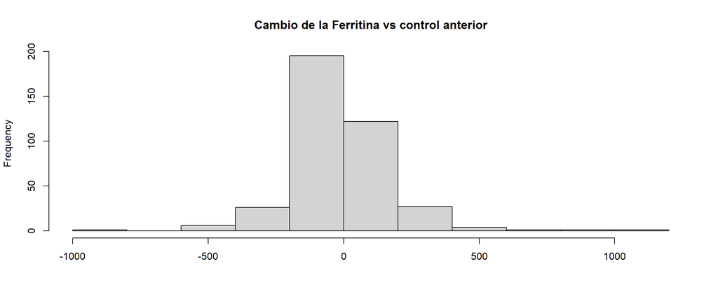

## Efecto no-lineal del factor tiempo

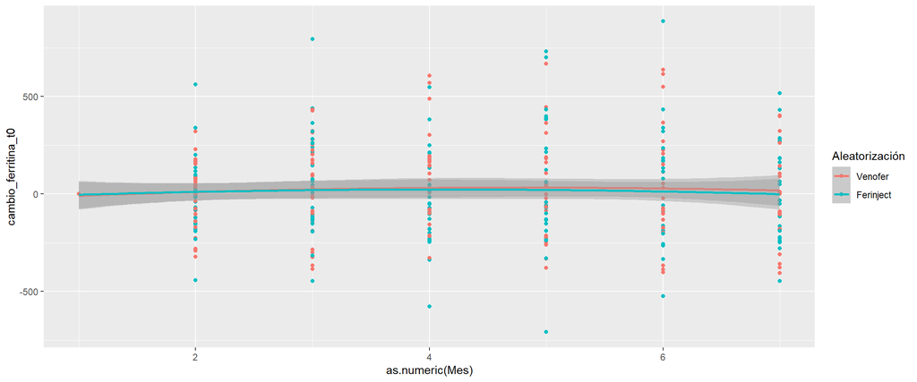

```
Data: mutate(filter(df, Vivo == 1), Mes = as.numeric(Mes))
Models:
fits$grado_1: cambio_ferritina_t0 ~ Aleatorización + poly(Mes, g, raw = TRUE) + (1 | id)
fits$grado_2: cambio_ferritina_t0 ~ Aleatorización + poly(Mes, g, raw = TRUE) + (1 | id)
fits$grado_3: cambio_ferritina_t0 ~ Aleatorización + poly(Mes, g, raw = TRUE) + (1 | id)
fits$grado_4: cambio_ferritina_t0 ~ Aleatorización + poly(Mes, g, raw = TRUE) + (1 | id)
             npar    AIC    BIC  logLik -2*log(L)  Chisq Df Pr(>Chisq)
fits$grado_1    5 5095.7 5115.4 -2542.8    5085.7
fits$grado_2    6 5096.1 5119.8 -2542.0    5084.1 1.6097  1     0.2045
fits$grado_3    7 5097.9 5125.5 -2541.9    5083.9 0.2048  1     0.6509
fits$grado_4    8 5099.8 5131.4 -2541.9    5083.8 0.0480  1     0.8265
```

```
--- Interpretación ---
```

```
Modelo recomendado: grado_1
```

```
grado_1 vs grado_2 : el modelo complejo grado_2 NO mejora significativamente respecto a grado_1 (p = 0.2045 )
grado_2 vs grado_3 : el modelo complejo grado_3 NO mejora significativamente respecto a grado_2 (p = 0.6509 )
grado_3 vs grado_4 : el modelo complejo grado_4 NO mejora significativamente respecto a grado_3 (p = 0.8265 )
```

**Implicación clínica**

No se observa evidencia estadística, según el test de razón de verosimilitudes, de que añadir términos de curvatura mejore el ajuste del modelo. Por tanto, la evolución de la ferritina es compatible con una relación aproximadamente lineal en el tiempo. La curvatura aparente podría deberse a variabilidad individual (capturada por `(1 | id)`) o a ruido